# Morris Screening

Jason Hilton

23 May 2019

Define a funky test function

$$y= \beta_0 + \beta_1x_1 + \beta_2x_1x_2 + \beta_4x_1^4 + \beta_5\text{sin}(4x_2\pi)$$

```r
library(tibble)
```

```r
library(ggplot2)
library(magrittr)
library(DiceKriging)
library(sensitivity)
library(lhs)
library(dplyr)
set.seed(1434)
test_function <- function(X, B){
  cbind(1, X, X[,1] * X[,2], X[,1]*X[,1]*X[,1]*X[,1],
        sin(X[,2]*4*pi)) %*% as.matrix(B)
}

# define the true function so that it ignores any additional columns of X
get_true_function <- function(true_beta){
  true_func <- function(X){
    test_function(X[,1:2], true_beta)
  }
  return(true_func)
}

# some arbitrary coefficients
true_beta <- c(3,-0.5,0.25, 2, -1/10,1)
true_function  <- get_true_function(true_beta)
```

What does this look like

```r
k <- 2
N <- 100
x <- seq(0,1, 0.05)

# generate a simple grid like design for ease of plotting
X <- as.matrix(expand.grid(replicate(k, x, simplify = F)))
# Observations
Y <- true_function(X)

# stick this in a single dataset
X_df <- as_tibble(X) %>% mutate(y=Y)
X_df
```

```
## # A tibble: 441 x 3
##     Var1  Var2 y[,1]
##    <dbl> <dbl> <dbl>
##  1  0        0  3
##  2  0.05     0  2.97
##  3  0.1      0  2.95
##  4  0.15     0  2.92
##  5  0.2      0  2.90
##  6  0.25     0  2.87
##  7  0.3      0  2.85
##  8  0.35     0  2.82
##  9  0.4      0  2.80
## 10  0.45     0  2.77
## # ... with 431 more rows
```

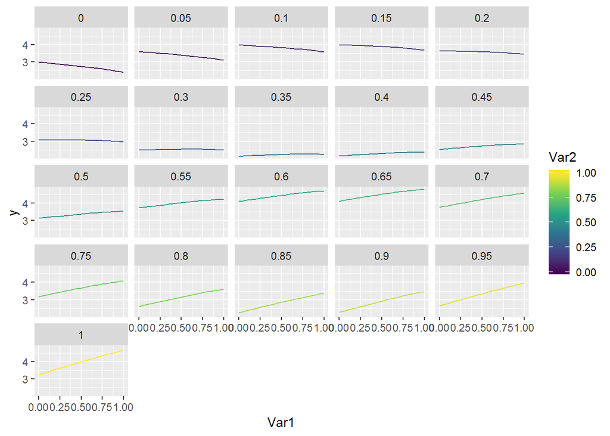

```r
ggplot(X_df,aes(x=Var1,y=y, colour=Var2)) + geom_line()+ scale_colour_viridis_c() +
  facet_wrap(~Var2)
```

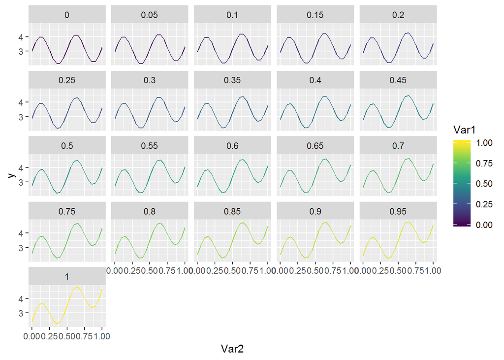

```r
ggplot(X_df,aes(x=Var2,y=y, colour=Var1)) + geom_line()+ scale_colour_viridis_c() +
  facet_wrap(~Var1)
```

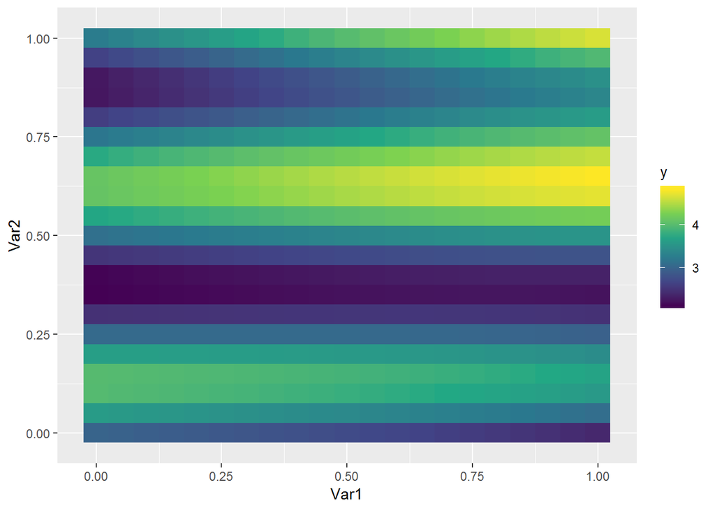

```r
ggplot(X_df, aes(x=Var1, y=Var2, fill=y)) + geom_tile() + scale_fill_viridis_c()
```

# Morris method

This method picks somepoints in design space and generates very simple paths through parameter space starting from each point, varying one input at a time (One-At-a-Time (OAT)). The mean effect on the output of the variation in each direction and the variance of these (accross sample starting points) describe the linear and non-linear effects of each variable.

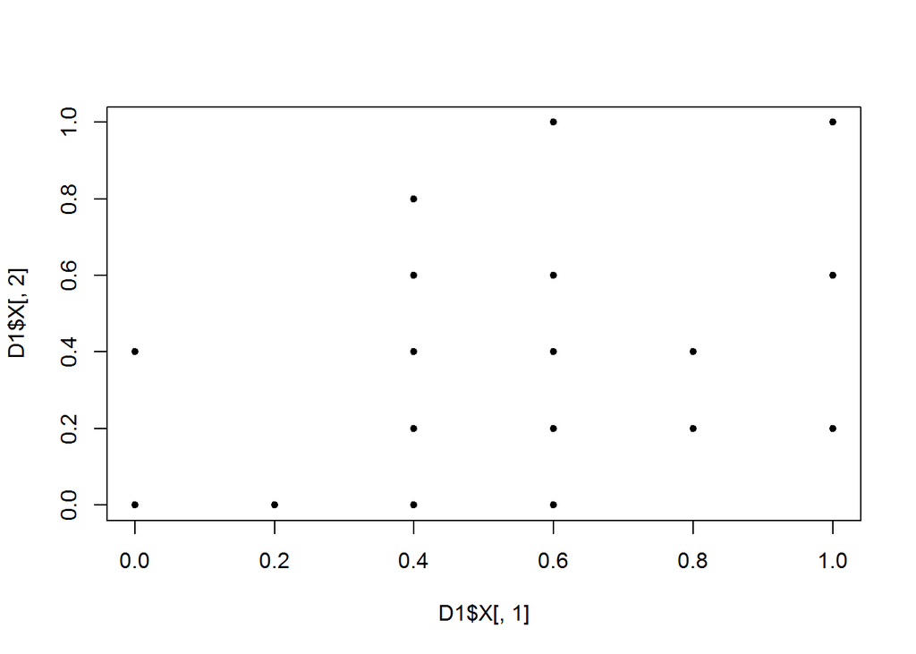

```r
# is the number of points
D1 <- morris(factors=20, r=10,
       design=list(type="oat",
                   levels=6,grid.jump=2))


plot(D1$X[,1], D1$X[,2]) #
```

Generate the outputs from these points. All linear and not linear effects are zero, except the ones we want to keep.

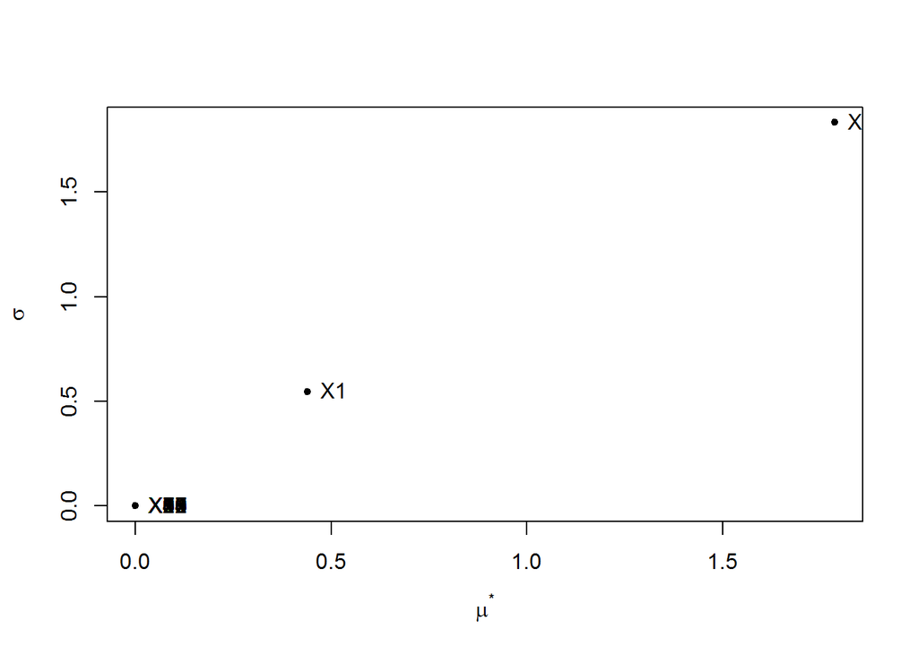

```r
Y1 <- true_function(D1$X)
tell(D1, Y1) # Modifies the morris object D1
plot(D1)
```

```r
print(D1)
```

```
##
## Call:
## morris(factors = 20, r = 10, design = list(type = "oat", levels = 6,     grid.jump = 2))
##
## Model runs: 210
## mu :
##          [,1]
## X1  0.1297600
## X2  0.8838504
## X3  0.0000000
## X4  0.0000000
## X5  0.0000000
## X6  0.0000000
## X7  0.0000000
## X8  0.0000000
## X9  0.0000000
## X10 0.0000000
## X11 0.0000000
## X12 0.0000000
## X13 0.0000000
## X14 0.0000000
## X15 0.0000000
## X16 0.0000000
## X17 0.0000000
## X18 0.0000000
## X19 0.0000000
## X20 0.0000000
##
## mu.star :
##         [,1]
## X1  0.440160
## X2  1.785963
## X3  0.000000
## X4  0.000000
## X5  0.000000
## X6  0.000000
## X7  0.000000
## X8  0.000000
## X9  0.000000
## X10 0.000000
```

[output cut: 18 more lines]

```
## X6  0.0000000
## X7  0.0000000
## X8  0.0000000
## X9  0.0000000
## X10 0.0000000
## X11 0.0000000
## X12 0.0000000
## X13 0.0000000
## X14 0.0000000
## X15 0.0000000
## X16 0.0000000
## X17 0.0000000
## X18 0.0000000
## X19 0.0000000
## X20 0.0000000
```

What if we add noise? If we add too much we obviously won’t be able to distinguish the signal. Let’s add one fifth the real signal. This seems to be ok. There are some distributional arguments about the threshold level of sigma.

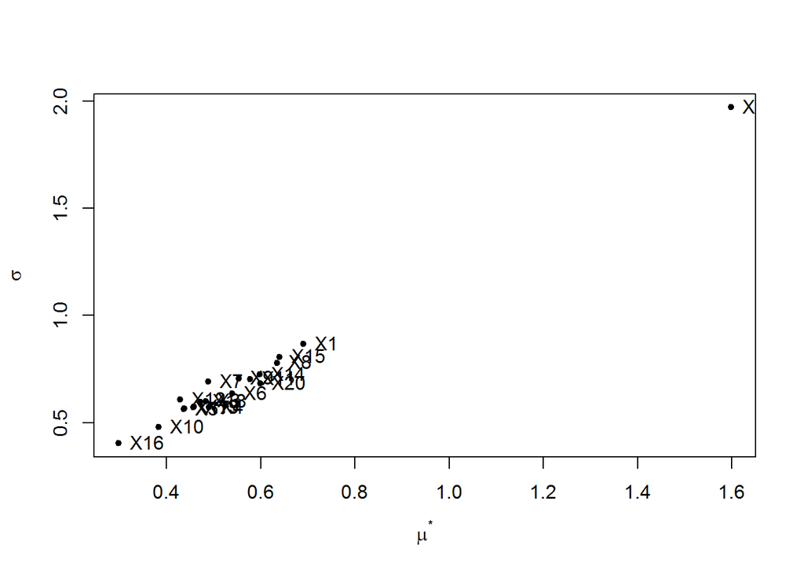

```r
noise_sig <- sd(Y1)/5

D2 <- morris(factors=20, r=25,
       design=list(type="oat",
                   levels=6,
                   grid.jump=2))

nobs <- dim(D2$X)[1]

Y2 <- true_function(D2$X) + rnorm(nobs, 0, noise_sig)
tell(D2, Y2) # Modifies the morris object D1
plot(D2)
```

```r
print(D2)
```

```
##
## Call:
## morris(factors = 20, r = 25, design = list(type = "oat", levels = 6,     grid.jump = 2))
##
## Model runs: 525
## mu :
##             [,1]
## X1   0.085243527
## X2   0.525979992
## X3  -0.053996534
## X4  -0.043431027
## X5  -0.153098631
## X6   0.220448884
## X7   0.029934280
## X8  -0.112467187
## X9   0.151757806
## X10  0.083367009
## X11  0.233380875
## X12 -0.028110490
## X13  0.036032454
## X14 -0.007709939
## X15  0.001694600
## X16  0.018876744
## X17  0.060121683
## X18  0.074513548
## X19 -0.057109958
## X20  0.259798104
##
## mu.star :
##          [,1]
## X1  0.6904499
## X2  1.5982863
## X3  0.4830152
## X4  0.4894843
## X5  0.4359646
## X6  0.5394108
## X7  0.4884834
## X8  0.6339785
## X9  0.5528145
## X10 0.3829110
```

[output cut: 18 more lines]

```
## X6  0.6350858
## X7  0.6902455
## X8  0.7783539
## X9  0.7061077
## X10 0.4790213
## X11 0.7032992
## X12 0.6074858
## X13 0.5708122
## X14 0.7251559
## X15 0.8072872
## X16 0.4040153
## X17 0.5668284
## X18 0.5982195
## X19 0.5738976
## X20 0.6819788
```

How does the kriging model do in the screened and non-screened spaces? Fit the models using the DiceKriging packages.

```r
# build an lhs sample in the higher and lower dimensional spaces
D1<-lhs::maximinLHS(n=400, k=2, method = "build", dup=4)
D2<-lhs::maximinLHS(n=400, k=10, method = "build", dup=4)
D3<-lhs::maximinLHS(n=400, k=20, method = "build", dup=4)
Y1 <- true_function(D1)
nug_var <- sd(Y1)/5
Y1 <- Y1 + rnorm(length(Y1), 0, sd(Y1)/5)
Y2 <- true_function(D2) + rnorm(length(Y1), 0, sd(Y1)/5)
Y3 <- true_function(D3) + rnorm(length(Y1), 0, sd(Y1)/5)

D1_df <- as_tibble(D1)
D2_df <- as_tibble(D2)
D3_df <- as_tibble(D3)
# constant mean
mod1 <- km(Y~1, D1,Y1, covtype="gauss", nugget.estim = T)
```

[output not shown]

```r
mod1
```

```
##
## Call:
## km(formula = Y ~ 1, design = D1, response = Y1, covtype = "gauss",
##     nugget.estim = T)
##
## Trend  coeff.:
##                Estimate
##  (Intercept)     2.8066
##
## Covar. type  : gauss
## Covar. coeff.:
##                Estimate
##    theta(X1)     1.9953
##    theta(X2)     0.1995
##
## Variance estimate: 2.976487
##
## Nugget effect estimate: 0.02062329
```

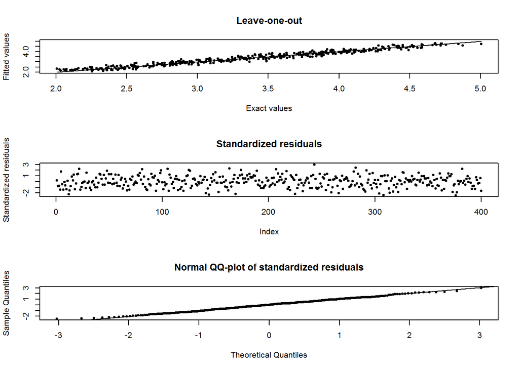

```r
plot(mod1)
```

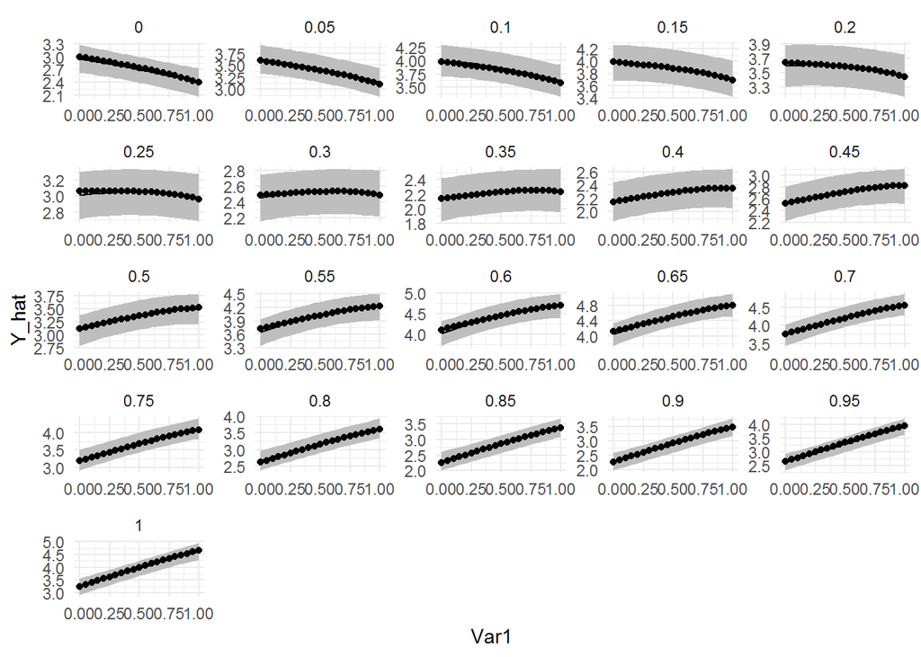

```r
# predict using our grid from before
X_df<- as_tibble(X[,1:2])
mod1_pred <- predict(mod1, newdata=X_df, checkNames=F,
                 type="SK") # SK for simple kriging - i.e. no linear trend in the mean function


X_df %<>% mutate(Y=true_function(X),
                 Y_hat=mod1_pred$mean,
                 Y_low=mod1_pred$lower95,
                 Y_hi=mod1_pred$upper95,
                 Error=Y-Y_hat,
                 Abs_error=abs(Error),
                 PC_error= Abs_error/Y)

ggplot(X_df, aes(x=Var1,y=Y_hat))  +
  facet_wrap(~Var2, scales="free") +
   geom_ribbon(aes(ymin=Y_low,ymax=Y_hi), fill="grey") +
  geom_line() +
  theme_minimal() +geom_point(aes(y=Y))
```

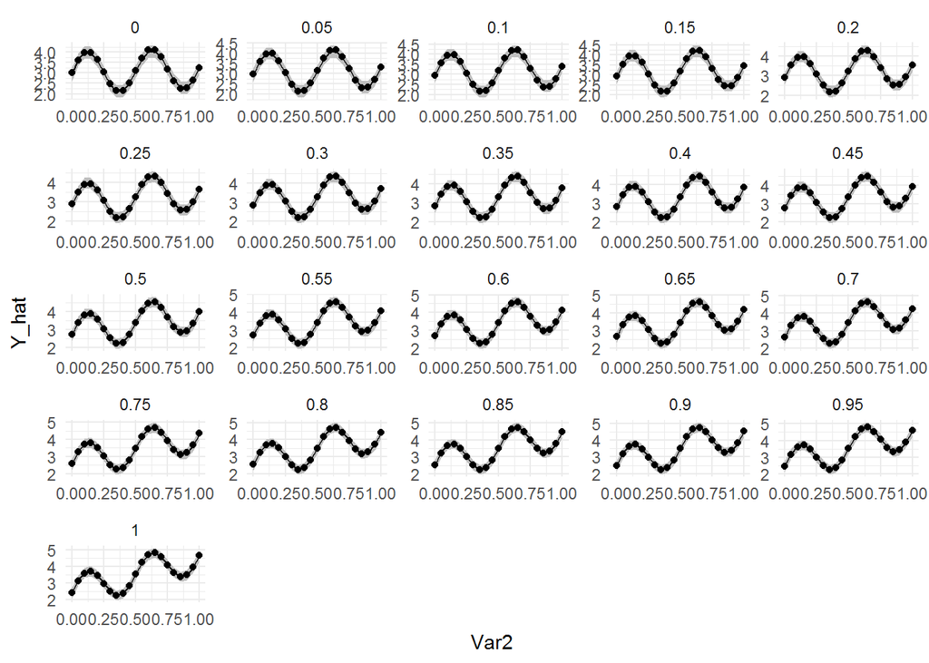

```r
ggplot(X_df, aes(x=Var2,y=Y_hat))  +
  facet_wrap(~Var1, scales="free") +
   geom_ribbon(aes(ymin=Y_low,ymax=Y_hi), fill="grey") +
  geom_line() +
  theme_minimal() +geom_point(aes(y=Y))
```

```r
X_df %>% summarise(mean(PC_error))
```

```
## # A tibble: 1 x 1
##   `mean(PC_error)`
##              <dbl>
## 1          0.00712
```

# 10 dimensions

```r
# constant mean
mod2 <- km(Y~1, D2,Y2, covtype="gauss", nugget.estim = T)
```

[output not shown]

```r
print(mod2)
```

```
##
## Call:
## km(formula = Y ~ 1, design = D2, response = Y2, covtype = "gauss",
##     nugget.estim = T)
##
## Trend  coeff.:
##                Estimate
##  (Intercept)     3.3189
##
## Covar. type  : gauss
## Covar. coeff.:
##                Estimate
##    theta(X1)     1.0894
##    theta(X2)     0.1135
##    theta(X3)     1.9975
##    theta(X4)     1.9974
##    theta(X5)     1.9979
##    theta(X6)     1.9931
##    theta(X7)     1.9930
##    theta(X8)     1.9932
##    theta(X9)     1.9945
##   theta(X10)     1.9964
##
## Variance estimate: 0.1957094
##
## Nugget effect estimate: 0.01742976
```

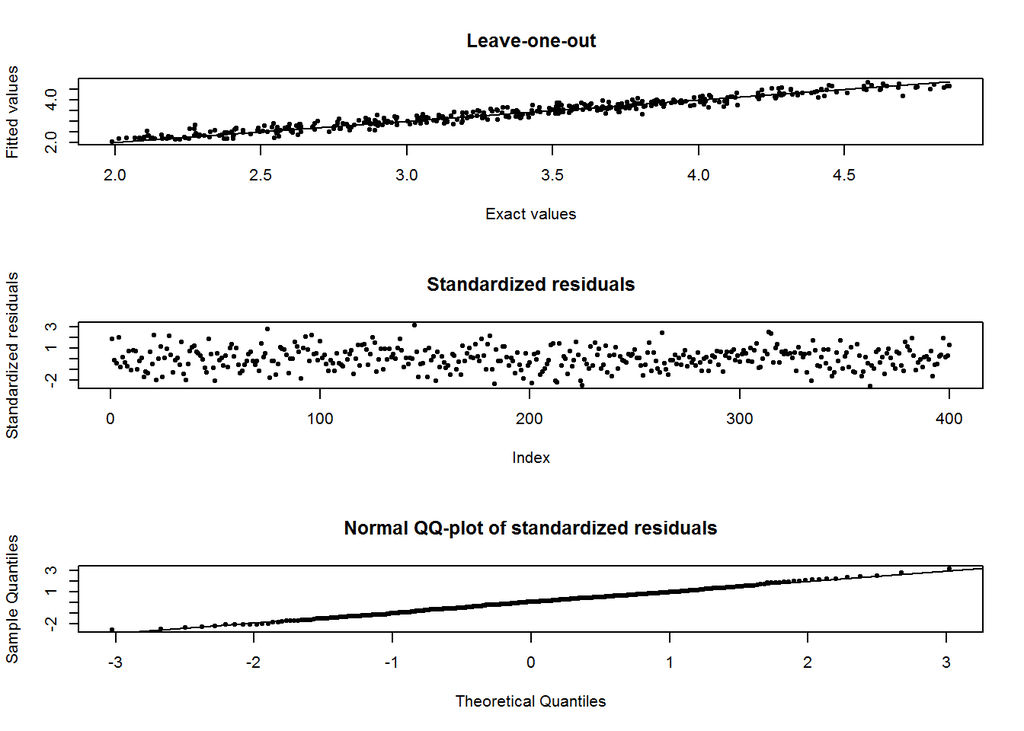

```r
plot(mod2)
```

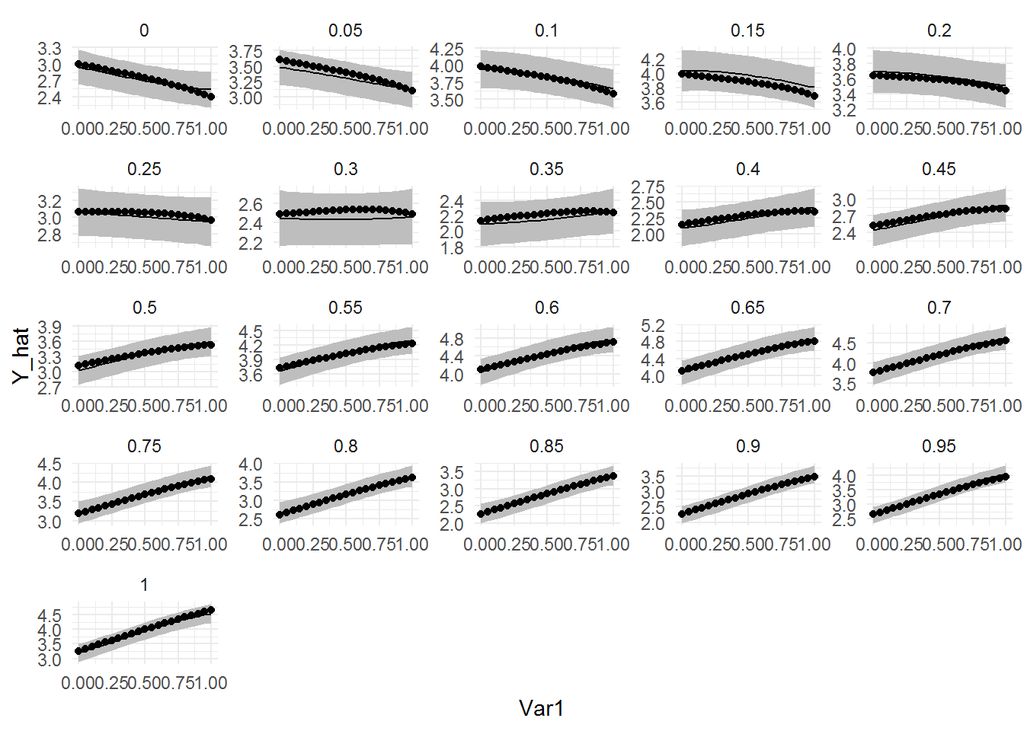

```r
X_df<- as_tibble(cbind(X[,1:2], matrix(0.5, dim(X)[1], 8)))
mod2_pred <- predict(mod2, newdata=X_df, checkNames=F,
                 type="SK") # SK for simple kriging - i.e. no linear trend in the mean function


X_df %<>% mutate(Y=true_function(X),
                 Y_hat=mod2_pred$mean,
                 Y_low=mod2_pred$lower95,
                 Y_hi=mod2_pred$upper95,
                 Error=Y-Y_hat,
                 Abs_error=abs(Error),
                 PC_error= Abs_error/Y)

ggplot(X_df, aes(x=Var1,y=Y_hat))  +
  facet_wrap(~Var2, scales="free") +
   geom_ribbon(aes(ymin=Y_low,ymax=Y_hi), fill="grey") +
  geom_line() +
  theme_minimal() +geom_point(aes(y=Y))
```

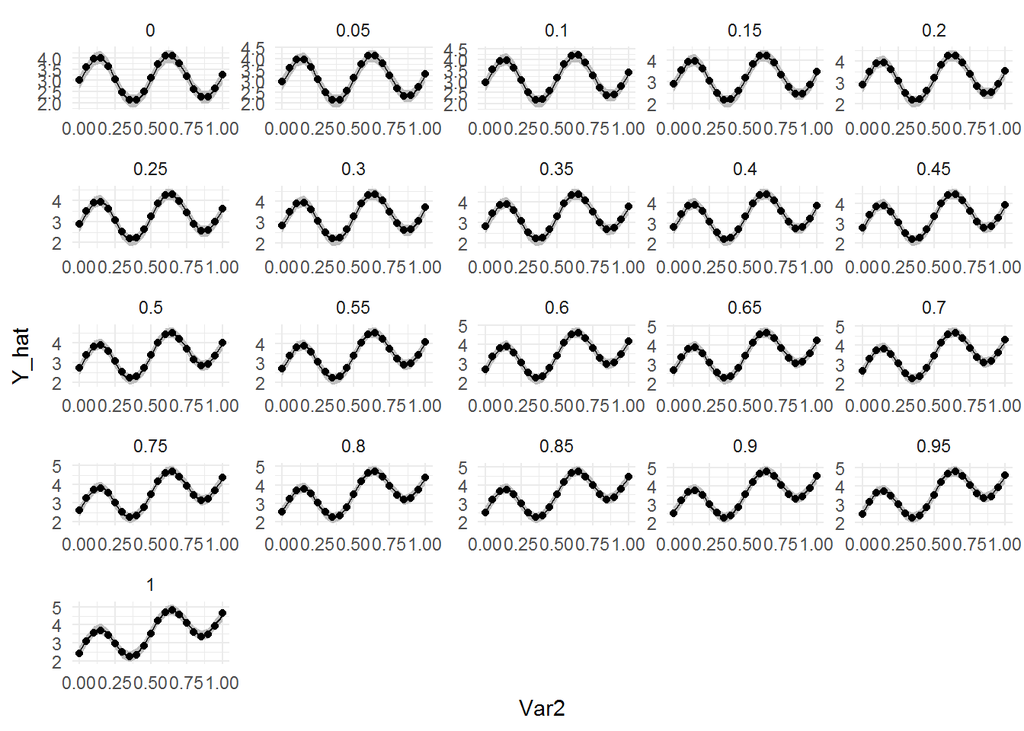

```r
ggplot(X_df, aes(x=Var2,y=Y_hat))  +
  facet_wrap(~Var1, scales="free") +
   geom_ribbon(aes(ymin=Y_low,ymax=Y_hi), fill="grey") +
  geom_line() +
  theme_minimal() +geom_point(aes(y=Y))
```

```r
X_df %>% summarise(mean(PC_error))
```

```
## # A tibble: 1 x 1
##   `mean(PC_error)`
##              <dbl>
## 1           0.0145
```

# 20 Dimensions

```r
mod3 <- km(Y~1, D3,Y3, covtype="gauss", nugget.estim = T)
```

[output not shown]

[output cut: 8 more lines]

[output not shown]

```r
print(mod3)
```

```
##
## Call:
## km(formula = Y ~ 1, design = D3, response = Y3, covtype = "gauss",
##     nugget.estim = T)
##
## Trend  coeff.:
##                Estimate
##  (Intercept)     3.2491
##
## Covar. type  : gauss
## Covar. coeff.:
##                Estimate
##    theta(X1)     0.7277
##    theta(X2)     0.0860
##    theta(X3)     1.9921
##    theta(X4)     1.9946
##    theta(X5)     1.9975
##    theta(X6)     1.9934
##    theta(X7)     1.9935
##    theta(X8)     1.9920
##    theta(X9)     1.9985
##   theta(X10)     1.9959
##   theta(X11)     1.9954
##   theta(X12)     1.9952
##   theta(X13)     1.9954
##   theta(X14)     1.9950
##   theta(X15)     1.9945
##   theta(X16)     1.9954
##   theta(X17)     1.9957
##   theta(X18)     1.9951
##   theta(X19)     1.9978
##   theta(X20)     1.9959
##
## Variance estimate: 0.1142276
##
## Nugget effect estimate: 0.01276638
```

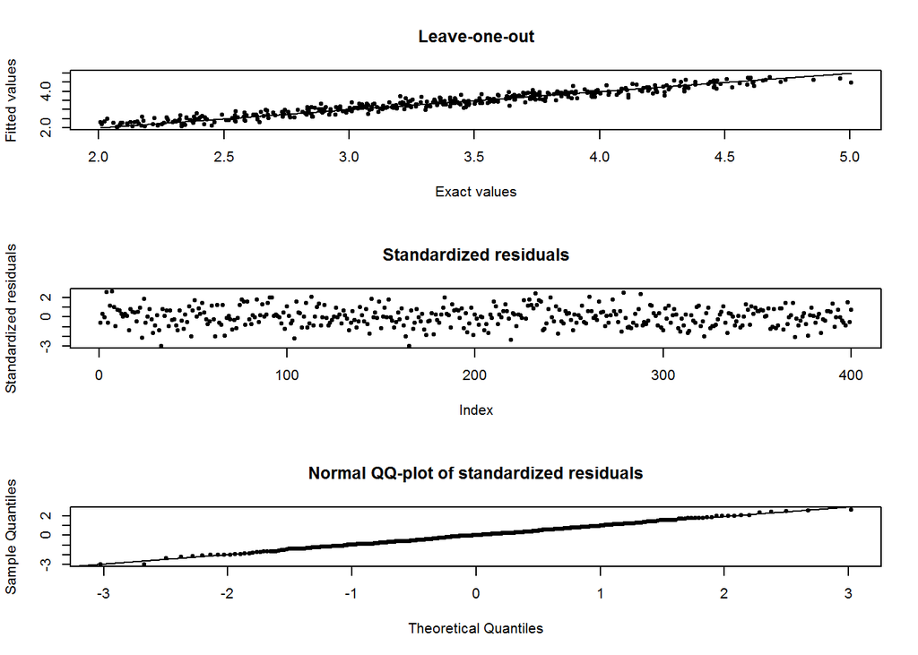

```r
plot(mod3)
```

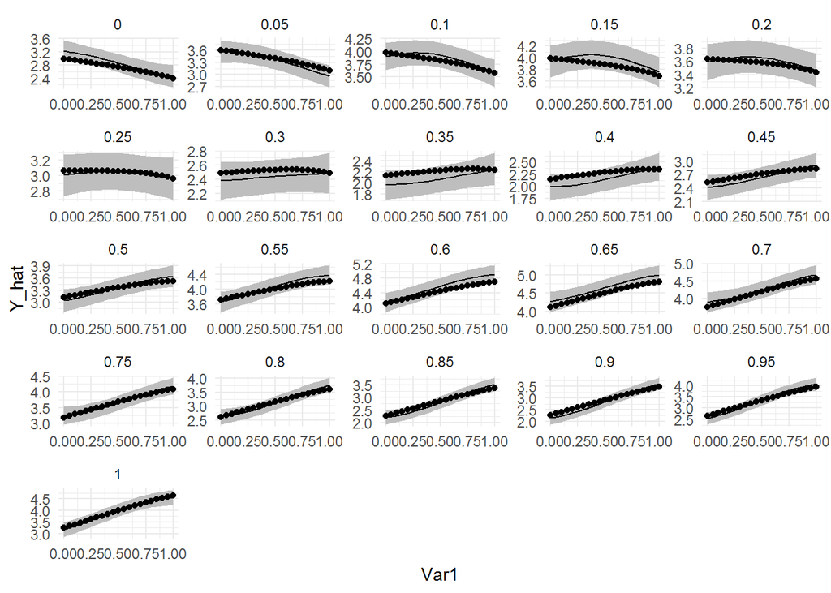

```r
X_df<- as_tibble(cbind(X[,1:2], matrix(0.5, dim(X)[1], 18)))
mod3_pred <- predict(mod3, newdata=X_df, checkNames=F,
                 type="SK") # SK for simple kriging - i.e. no linear trend in the mean function



X_df %<>% mutate(Y=true_function(X),
                 Y_hat=mod3_pred$mean,
                 Y_low=mod3_pred$lower95,
                 Y_hi=mod3_pred$upper95,
                 Error=Y-Y_hat,
                 Abs_error=abs(Error),
                 PC_error= Abs_error/Y)

ggplot(X_df, aes(x=Var1,y=Y_hat))  +
  facet_wrap(~Var2, scales="free") +
   geom_ribbon(aes(ymin=Y_low,ymax=Y_hi), fill="grey") +
  geom_line() +
  theme_minimal() +geom_point(aes(y=Y))
```

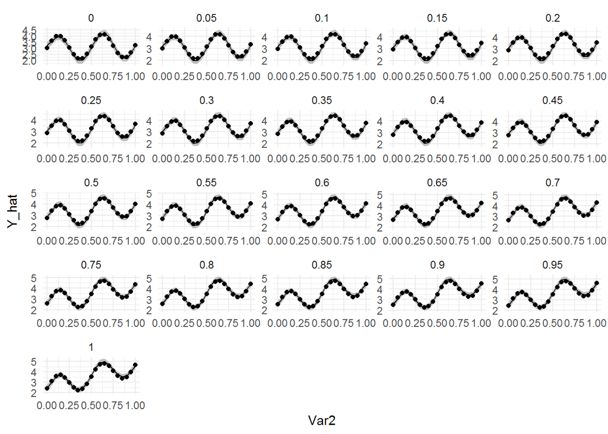

```r
ggplot(X_df, aes(x=Var2,y=Y_hat))  +
  facet_wrap(~Var1, scales="free") +
   geom_ribbon(aes(ymin=Y_low,ymax=Y_hi), fill="grey") +
  geom_line() +
  theme_minimal() +geom_point(aes(y=Y))
```

```r
X_df %>% summarise(mean(PC_error))
```

```
## # A tibble: 1 x 1
##   `mean(PC_error)`
##              <dbl>
## 1           0.0268
```

## Automatic Relevance detection

Higher points indicate relevance

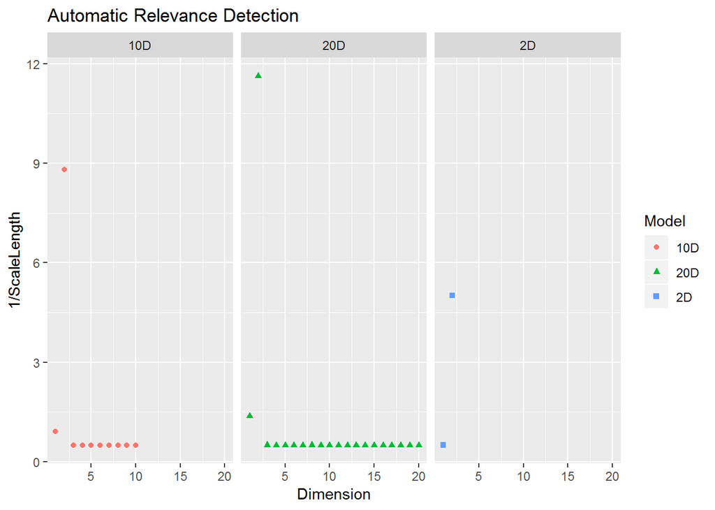

```r
ard_df <- rbind(tibble(Model="20D",
             ScaleLength=coef(mod3)$range,
             Dimension=1:20),
      tibble(Model="10D",
             ScaleLength=coef(mod2)$range,
             Dimension=1:10),
      tibble(Model="2D",
             ScaleLength=coef(mod1)$range,
             Dimension=1:2))


ggplot(ard_df, aes(x=Dimension, y= 1/ScaleLength,colour=Model,shape=Model))+
  geom_point() + ggtitle("Automatic Relevance Detection") + facet_wrap(~Model)
```

## Nugget estimates

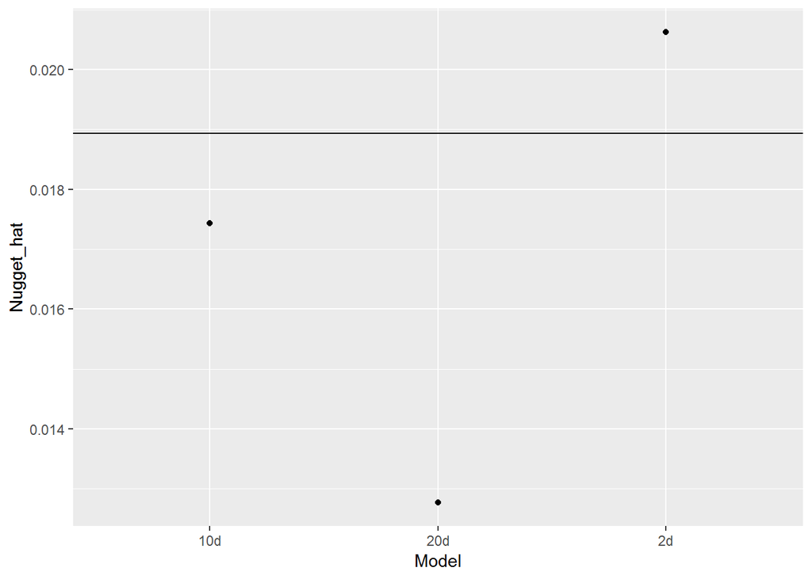

```r
nug_df <- tibble(Model=c("2d","10d","20d"),
       Nugget_hat= c(coef(mod1)$nugget,
                     coef(mod2)$nugget,
                     coef(mod3)$nugget),
       True_nugget=nug_var**2)

ggplot(nug_df, aes(x=Model,y=Nugget_hat)) + geom_point() +
  geom_hline(aes(yintercept=True_nugget))
```

## Sensitivity

Sensitivity analysis based on numerically probing the emulator and calculating Sobol indicies

```r
wrap_mod <- function(krig_model){
  predict_krig <- function(X){
    predict(krig_model, newdata=X, checkNames=F,
                 type="SK")$mean
  }
  return(predict_krig)
}


sens_f1<- wrap_mod(mod1)
x <- fast99(model = sens_f1, factors = c("X1","X2"), n = 1000,
            q = "qunif", q.arg = list(min = -pi, max = pi))

x
```

```
##
## Call:
## fast99(model = sens_f1, factors = c("X1", "X2"), n = 1000, q = "qunif",     q.arg = list(min = -pi, max = pi))
##
## Model runs: 2000
##
## Estimations of the indices:
##    first order total order
## X1  0.03332365   0.4248845
## X2  0.18729555   0.9174866
```

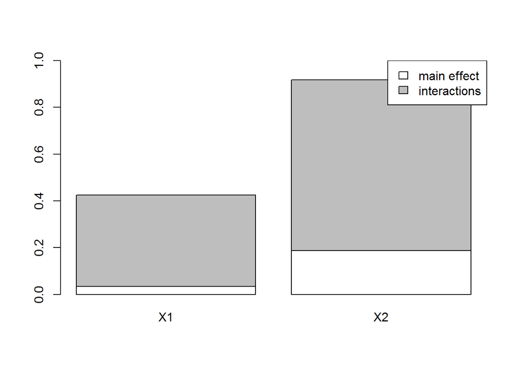

```r
plot(x)
```

```r
sens_f2<- wrap_mod(mod2)
x <- fast99(model = sens_f2, factors = 10, n = 5000,
            q = "qunif", q.arg = list(min = -pi, max = pi))

x
```

```
##
## Call:
## fast99(model = sens_f2, factors = 10, n = 5000, q = "qunif",     q.arg = list(min = -pi, max = pi))
##
## Model runs: 50000
##
## Estimations of the indices:
##       first order total order
## X1  0.00379445443   0.5435400
## X2  0.00624103597   0.8551544
## X3  0.00005421205   0.2930745
## X4  0.00032745947   0.2796809
## X5  0.00018622869   0.2769231
## X6  0.00021545740   0.2799412
## X7  0.00105021810   0.3189977
## X8  0.00019734100   0.2933530
## X9  0.00003212976   0.2875442
## X10 0.00014091479   0.3013218
```

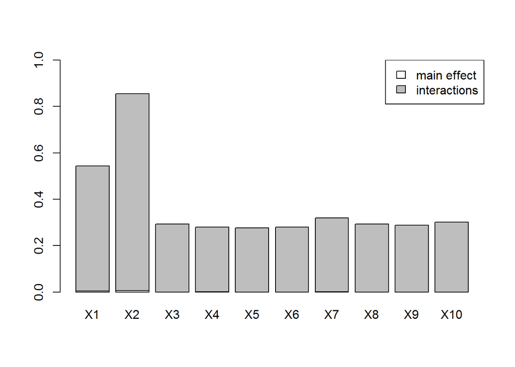

```r
plot(x)
```

### 20 Dimensions

```r
sens_f3<- wrap_mod(mod3)
x <- fast99(model = sens_f3, factors = 20, n = 10000,
            q = "qunif", q.arg = list(min = -pi, max = pi))

x
```

```
##
## Call:
## fast99(model = sens_f3, factors = 20, n = 10000, q = "qunif",     q.arg = list(min = -pi, max = pi))
##
## Model runs: 200000
##
## Estimations of the indices:
##      first order total order
## X1  0.0007433748   0.6317684
## X2  0.0002420631   0.9041117
## X3  0.0001557227   0.1775226
## X4  0.0001971253   0.1763244
## X5  0.0001681121   0.1673779
## X6  0.0002017415   0.1851616
## X7  0.0002822867   0.1880431
## X8  0.0001884045   0.1787726
## X9  0.0005157678   0.2204952
## X10 0.0001663281   0.2082819
## X11 0.0001883214   0.1943943
## X12 0.0001489308   0.1975105
## X13 0.0001743466   0.2020364
## X14 0.0002021088   0.1978959
## X15 0.0003595090   0.2352706
## X16 0.0004329198   0.2207428
## X17 0.0001566416   0.1778960
## X18 0.0002248256   0.1923875
## X19 0.0001552935   0.1973018
## X20 0.0002601277   0.2148369
```

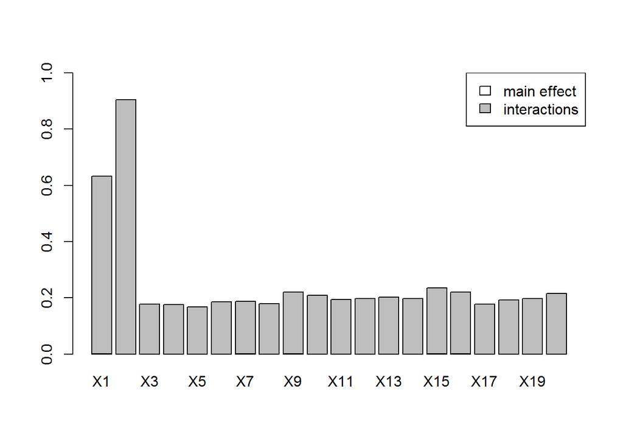

```r
plot(x)
```